# hw3 YG

#2:

```r
library(tidytext)
library(dplyr)

tokens_with_stop <- pubmed %>%
  unnest_tokens(word, abstract) %>%
  count(term, word, sort = TRUE)

top5_with_stop <- tokens_with_stop %>%
  group_by(term) %>%
  slice_max(order_by = n, n = 5)

top5_with_stop
```

```
# A tibble: 25 × 3
# Groups:   term [5]
   term            word      n
   <chr>           <chr> <int>
 1 covid           the    9741
 2 covid           of     7668
 3 covid           covid  7275
 4 covid           19     7035
 5 covid           and    6861
 6 cystic fibrosis the    2677
 7 cystic fibrosis of     2304
 8 cystic fibrosis and    1777
 9 cystic fibrosis in     1497
10 cystic fibrosis to     1011
# ℹ 15 more rows
```

```r
data("stop_words")

tokens_no_stop <- pubmed %>%
  unnest_tokens(word, abstract) %>%
  anti_join(stop_words, by = "word") %>%
  count(term, word, sort = TRUE)

top5_no_stop <- tokens_no_stop %>%
  group_by(term) %>%
  slice_max(order_by = n, n = 5)

top5_no_stop
```

```
# A tibble: 25 × 3
# Groups:   term [5]
   term            word         n
   <chr>           <chr>    <int>
 1 covid           covid     7275
 2 covid           19        7035
 3 covid           patients  2293
 4 covid           disease    943
 5 covid           pandemic   800
 6 cystic fibrosis fibrosis   867
 7 cystic fibrosis cystic     862
 8 cystic fibrosis cf         625
 9 cystic fibrosis patients   586
10 cystic fibrosis disease    400
# ℹ 15 more rows
```

```r
library(knitr)
library(kableExtra)

kable(top5_no_stop,
      caption = "Top 5 Tokens per Search Term After Removing Stop Words",
      col.names = c("Search Term", "Token (Word)", "Count"),
      align = c("l", "l", "r")) %>%
  kable_styling(full_width = FALSE, bootstrap_options = c("striped", "hover", "condensed")) %>%
  row_spec(0, bold = TRUE, color = "white", background = "#2e8b57") %>%
  column_spec(1:3, background = "#e9f7ef")
```

Top 5 Tokens per Search Term After Removing Stop Words

| Search Term | Token (Word) | Count |
| --- | --- | --- |
| covid | covid | 7275 |
| covid | 19 | 7035 |
| covid | patients | 2293 |
| covid | disease | 943 |
| covid | pandemic | 800 |
| cystic fibrosis | fibrosis | 867 |
| cystic fibrosis | cystic | 862 |
| cystic fibrosis | cf | 625 |
| cystic fibrosis | patients | 586 |
| cystic fibrosis | disease | 400 |
| meningitis | patients | 446 |
| meningitis | meningitis | 429 |
| meningitis | meningeal | 219 |
| meningitis | csf | 206 |
| meningitis | clinical | 187 |
| preeclampsia | pre | 2038 |
| preeclampsia | eclampsia | 2005 |
| preeclampsia | preeclampsia | 1863 |
| preeclampsia | women | 1196 |
| preeclampsia | pregnancy | 969 |
| prostate cancer | cancer | 3840 |
| prostate cancer | prostate | 3832 |
| prostate cancer | patients | 934 |
| prostate cancer | treatment | 926 |
| prostate cancer | disease | 652 |

before and after:

```r
tokens_with_stop <- pubmed %>%
  unnest_tokens(word, abstract) %>%
  count(term, word, sort = TRUE)

data("stop_words")
tokens_no_stop <- pubmed %>%
  unnest_tokens(word, abstract) %>%
  anti_join(stop_words, by = "word") %>%
  count(term, word, sort = TRUE)
top5_with_stop <- tokens_with_stop %>%
  group_by(term) %>%
  slice_max(order_by = n, n = 5) %>%
  summarise(Top_Words_Before = paste(word, collapse = ", "))

top5_no_stop <- tokens_no_stop %>%
  group_by(term) %>%
  slice_max(order_by = n, n = 5) %>%
  summarise(Top_Words_After = paste(word, collapse = ", "))

comparison_table <- left_join(top5_with_stop, top5_no_stop, by = "term") %>%
  rename(Search_Term = term)

kable(comparison_table,
      caption = "Comparison of Top 5 Tokens Before vs After Removing Stop Words",
      align = c("l", "l", "l"),
      col.names = c("Search Term", "Top 5 Tokens (Before)", "Top 5 Tokens (After)")) %>%
  kable_styling(full_width = FALSE, bootstrap_options = c("striped", "hover", "condensed")) %>%
  row_spec(0, bold = TRUE, color = "white", background = "#2e8b57") %>%
  column_spec(1:3, background = "#e9f7ef")
```

Comparison of Top 5 Tokens Before vs After Removing Stop Words

| Search Term | Top 5 Tokens (Before) | Top 5 Tokens (After) |
| --- | --- | --- |
| covid | the, of, covid, 19, and | covid, 19, patients, disease, pandemic |
| cystic fibrosis | the, of, and, in, to | fibrosis, cystic, cf, patients, disease |
| meningitis | the, of, and, in, a | patients, meningitis, meningeal, csf, clinical |
| preeclampsia | the, of, and, in, to | pre, eclampsia, preeclampsia, women, pregnancy |
| prostate cancer | the, of, and, cancer, prostate | cancer, prostate, patients, treatment, disease |

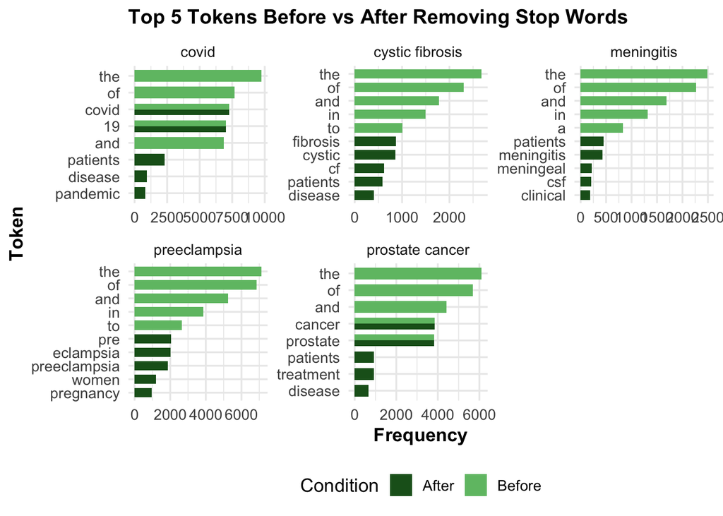

```r
tokens_with_stop$condition <- "Before"
tokens_no_stop$condition <- "After"

combined_tokens <- bind_rows(tokens_with_stop, tokens_no_stop)

top_tokens <- combined_tokens %>%
  group_by(term, condition) %>%
  slice_max(order_by = n, n = 5)

ggplot(top_tokens, aes(x = reorder_within(word, n, term), y = n, fill = condition)) +
  geom_col(position = "dodge", width = 0.7) +
  facet_wrap(~term, scales = "free") +
  coord_flip() +
  scale_x_reordered() +
  scale_fill_manual(values = c("Before" = "#6fbf73", "After" = "#1b5e20")) +
  labs(
    title = "Top 5 Tokens Before vs After Removing Stop Words",
    x = "Token",
    y = "Frequency",
    fill = "Condition"
  ) +
  theme_minimal(base_size = 13) +
  theme(
    plot.title = element_text(face = "bold", size = 14),
    axis.title = element_text(face = "bold"),
    legend.position = "bottom"
  )
```

Before eliminating stop words, the most frequent tokens were general English terms like the, and, and of, which provide little analytical value in biomedical text mining. Once stop words were removed, the top tokens reflected domain-specific and meaningful biological concepts — for instance, “covid” and “patients” in COVID-19 studies, “cancer” and “prostate” in prostate cancer research, and “preeclampsia” and “pregnancy” in maternal health topics. This demonstrates that removing stop words substantially enhances the clarity and relevance of token frequency analyses.